# Effect of vaccination on the rate of fatality over WHO regions

# 4 Descriptive analysis

Since there are huge amount variables in the original dataset, so it is instrumental to filter out the main variables, which can make following analysis much easier. After filtering the variables, deleting the missing value is the next important step. A new dataset with no missing values and containing multiple main variables obtained. Base on the background information and my assumption, it is necessary to find the vaccination starting date for each country and mark whether vaccine exists on each of reported date. However, the spread of virus may be delayed in some regions since it takes some time to spread from one country to another, therefore, after finding average fatality rate,deleting new cases which are zero from the final dataset is required since these data will lead to an inaccurate mean for all WHO region.

Mean of fatality rate on WHO_region with vaccination v.s without vaccination

```
##    WHO_region v_exist mean_size
## 1        AFRO      no  2.276180
## 2        AFRO     yes  2.462653
## 3        AMRO      no  3.245719
## 4        AMRO     yes  2.595085
## 5        EMRO      no  3.971873
## 6        EMRO     yes  4.222925
## 7        EURO      no  3.359853
## 8        EURO     yes  2.280415
## 9       SEARO      no  1.908434
## 10      SEARO     yes  1.562211
## 11       WPRO      no  2.376714
## 12       WPRO     yes  1.645088
```

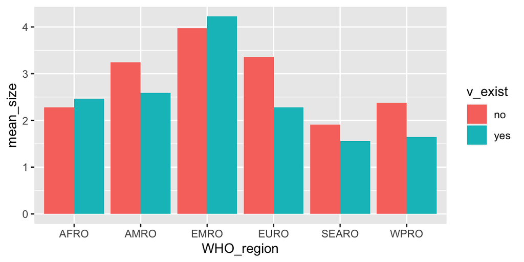

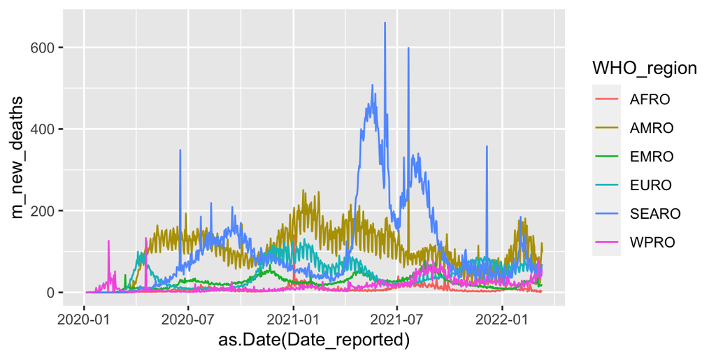

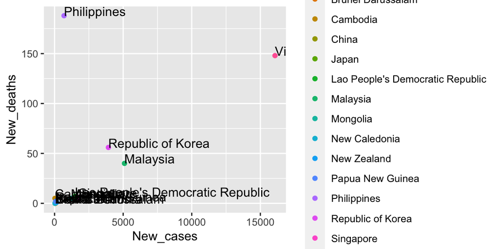

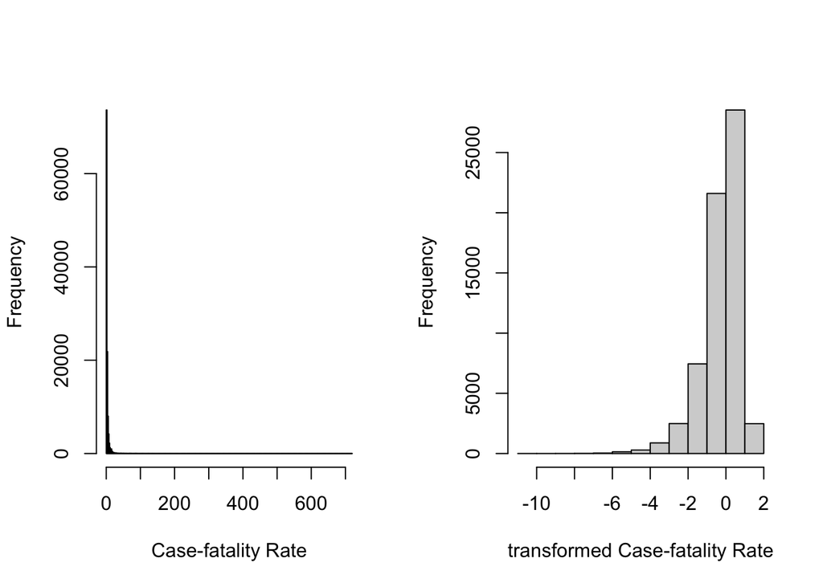

```r
#histogram of avg death rate
par(mfrow = c(1,2))
hist(m_data$ave_fatality_rate,  breaks = 500, xlab = 'Case-fatality Rate', main = '')
m_data$tave_fatality_rate = log(m_data$ave_fatality_rate + 0.00001)
hist( log(m_data$tave_fatality_rate + 0.00001),  xlab = 'transformed Case-fatality Rate', main = '')
```

# 5 Inferential analysis

We can define a two-way ANOVA model as follows: $Y_{ijk}$=$\mu_{ij}$+$\alpha_{i}$+$\beta_{j}$+$\epsilon_{ijk}$, where the index i represents the class type: AFRO (i=1), AMRO (i=2), EMRO (i=3), EURO (i=4), SEARO (1 =5), WPRO (i=6) and the index j represents the existence of vaccination (yes: exist vaccination; no: otherwise. The $\mu_{ij}$ indicates theoretical mean or expected value of every seven days’ fatality rate in cell (i, j), and the $\epsilon_{ijk}$ are i.i.d. N(0,$\sigma^2$). There are $\alpha\beta$ unknown means and one unknown σ in the cell means model.Write down the factor effect form with constraints:$Y{ijk}$=$\mu_{..}$+$\alpha_{i}$+$\beta_{j}$+ $(\alpha\beta)_{ij}$+$\epsilon_{ijk}$, i = 1,2,3,4,5,6, and j = yes/no.

To find the best model, it is essential to compare the full model and reduced model to decide whether interaction term has a significant effect to the model or not. The first step is to set a full model and a reduced model. And second, use anova function to compare the full model and reduced model. Through observing the ANOVA table, I found that the interaction term is significant to this model since this term has a extremely small p-value, which is smaller than 0.05. Therefore, dropping the interaction term is not recommended, we should keep the interaction term.

```
## Analysis of Variance Table
##
## Model 1: tave_fatality_rate ~ as.factor(WHO_region) + as.factor(v_exist)
## Model 2: tave_fatality_rate ~ as.factor(WHO_region) + as.factor(v_exist) +
##     as.factor(v_exist) * as.factor(WHO_region)
##   Res.Df     RSS Df Sum of Sq      F    Pr(>F)
## 1 115228 2334925
## 2 115223 2321407  5     13518 134.19 < 2.2e-16 ***
## ---
## Signif. codes:  0 '***' 0.001 '**' 0.01 '*' 0.05 '.' 0.1 ' ' 1
```

## 5.1 F_test

```r
anova(full_model)
```

```
## Analysis of Variance Table
##
## Response: tave_fatality_rate
##                                              Df  Sum Sq Mean Sq F value
## as.factor(WHO_region)                         5   90011 18002.2  893.54
## as.factor(v_exist)                            1    8441  8441.5  418.99
## as.factor(WHO_region):as.factor(v_exist)      5   13518  2703.6  134.19
## Residuals                                115223 2321407    20.1
##                                             Pr(>F)
## as.factor(WHO_region)                    < 2.2e-16 ***
## as.factor(v_exist)                       < 2.2e-16 ***
## as.factor(WHO_region):as.factor(v_exist) < 2.2e-16 ***
## Residuals
## ---
## Signif. codes:  0 '***' 0.001 '**' 0.01 '*' 0.05 '.' 0.1 ' ' 1
```

#Equal Variance Test

```
##      AFRO      AMRO      EMRO      EURO     SEARO      WPRO
##  15.80646  24.86540 249.72118  49.24127  20.55316  34.65532
```

Moreover, doing a Levene test is another good idea to justify if samples have equal variances. Define the null hypothesis $H_{0}$: $\sigma_{1}^2$, $\sigma_{2}^2$ ,$\sigma_{3}^2$,$\sigma_{4}^2$, $\sigma_{5}^2$, $\sigma_{6}^2$ against the alternative $H_{1}$: not all variance are equal. After conducting the Levene test, the p value is very small, less that 0.05, which indicates we should reject the null hypothesis at significance level $\alpha$ = 0.05. Therefore, we conclude that not all variance are equal.

```
## Levene's Test for Homogeneity of Variance (center = median)
##           Df F value    Pr(>F)
## group     11  58.758 < 2.2e-16 ***
##       115223
## ---
## Signif. codes:  0 '***' 0.001 '**' 0.01 '*' 0.05 '.' 0.1 ' ' 1
```